```python
import requests
import datetime
import re
import locale
import urllib.request
import pandas as pd
import numpy as np
import matplotlib.pyplot as plt
from bs4 import BeautifulSoup
from sklearn.linear_model import LinearRegression
import matplotlib.lines as mlines
import matplotlib
import shapefile as shp
```

# **I. Récupération du dataframe "Classements"**

Les explications pas à pas des différentes étapes de chargement et nettoyage des données figurent dans la version "detailed" du Notebook, restituée également via le Github.

```python
def conver_DM_to_GPS(df,col):
    df_coord_tmp=df[('Last signal',col)].str.extract(('(\d*)°(\d*.\d*)\'(.)'))
    df_coord_tmp.set_axis(['deg','min','sign'],axis=1,inplace=True)
    df_coord_tmp['sign']=df_coord_tmp['sign'].map({'W':-1,'E':1,'S':-1,'N':1})
    df_coord_tmp=df_coord_tmp.applymap(lambda x : pd.to_numeric(x))
    return ((df_coord_tmp['deg']+df_coord_tmp['min']/60)*df_coord_tmp['sign'])

def load_and_clean_rankings():

    # AQUISITION ET CHARGEMENT

    # Génération d'une liste des dates et heures correspondant au nom de tous les fichiers classements
    hours=[datetime.time(x).strftime('%H%M%S') for x in [4,8,11,14,17,21]]
    first_full_day=datetime.date(2020,11,9)
    last_full_day=datetime.date(2021,1,26)
    full_days=last_full_day-first_full_day
    day=datetime.timedelta(days=1)
    days=[(first_full_day + i*day).strftime('%Y%m%d') for i in range(0,full_days.days+1)]
    days_hours=[f'{days[i]}_{hours[j]}.xlsx' for i in range(0,len(days)) for j in range(0,len(hours))]
    first_day_hours=['20201108_140000.xlsx','20201108_170000.xlsx','20201108_210000.xlsx']
    last_day_hours=['20210127_040000.xlsx','20210127_080000.xlsx','20210127_110000.xlsx','20210127_140000.xlsx']
    days_hours=first_day_hours+days_hours+last_day_hours

    # Telechargement des fichiers Excel de classement sur le site du Vendée Globe
    # Les lignes sont commentées car il s'agit d'instructions coûteuse qu'il est inutile de reproduire une fois les fichiers disponibles en local
    local_path='data/'
    link="https://www.vendeeglobe.org/download-race-data/vendeeglobe_"
    # for day_hour in days_hours:
    #     local_filename, headers = urllib.request.urlretrieve(link+day_hour,filename=local_path+day_hour)

    # Insertion du contenu de tous les fichiers de classement dans un grand data_frame, en insérant le date-time de publication de chaque classement comme colonne supplémentaire
    df=pd.DataFrame()
    for day_hour in days_hours:
        new_ranking_df=pd.read_excel("data/converted/"+day_hour+".xls",header=4,skiprows=range(38,42),usecols=range(1,21))
        datetime_value=pd.to_datetime(day_hour.strip('.xlsx'),format='%Y%m%d_%H%M%S')
        new_ranking_df['Ranking publication']=datetime_value
        df=df.append(new_ranking_df)

    # PREPARATION DES DONNEES

    # Suppression des \n dans les cellules qui en contiennent pour ne pas qu'elles polluent l'analyse par la suite
    df[df.columns[1]].replace('.*\n','',regex=True,inplace=True)
    df[df.columns[3]].replace('\n','',regex=True,inplace=True)
    df[df.columns[2]].replace('\n',' / ',regex=True,inplace=True)

    # Mise au propre du nom des colonnes à l'aide d'un multiindex
    lev1=['Last signal']+['Identification']*3+['Last signal']*2+["Last 30min"]*4+["Since last report"]*4+["Last 24h"]*4+['Last signal']*2+['Identification']
    lev2=['Rank','Sail N°','Skipper / Crew','Hour description','Latitude','Longitude','Heading (°)','Speed (kts)','VMG (kts)','Distance (nm)','Heading (°)',
          'Speed (kts)','VMG (kts)','Distance (nm)','Heading (°)','Speed (kts)','VMG (kts)','Distance (nm)','DTF (nm)','DTL (nm)','Ranking publication']
    list_tuples=list(zip(lev1,lev2))
    col_multi_index=pd.MultiIndex.from_tuples(list_tuples,names=['Category','Field'])
    df.set_axis(col_multi_index,axis=1,inplace=True)

    # Extraction de l'information relative à la date et à l'heure en créant de nouvelles colonnes plus explicites
    tmp=df[('Identification','Hour description')].str.extract('(\d\d:\d\d) FR(?:(-?\d\d?\d?)min)?')
    tmp=tmp.set_axis(['heure_desc','heure_offset'],axis=1)
    tmp['heure_desc']=pd.to_datetime(tmp['heure_desc'],format='%H:%M')
    tmp['heure_offset']=tmp['heure_offset'].apply(lambda x : datetime.timedelta(minutes=int(x)) if not pd.isna(x) else datetime.timedelta(minutes=0))
    tmp['heure_request']=(tmp['heure_desc']-tmp['heure_offset']).dt.strftime('%H:%M')
    df[('Identification','Signal request')]=pd.to_datetime(df[('Identification','Ranking publication')].dt.strftime('%d-%m-%Y')+' '+tmp['heure_request'],format='%d-%m-%Y %H:%M')
    df[('Identification','Signal reception')]=df[('Identification','Signal request')]+tmp['heure_offset']

    # Réordonnancement des colonnes dans un ordre logique
    df=df[['Identification','Last signal','Last 30min','Since last report','Last 24h']]

    # Traitemment (élimination après diagnostic) des valeurs nulles
    df=df.loc[df[('Last signal','Rank')]!='RET']
    df=df.loc[df[('Last signal','Rank')]!='NL']
    df.reset_index()

    # Conversion des colonnes numériques au format numérique
    df[('Last signal','Rank')]=pd.to_numeric(df[('Last signal','Rank')])
    df[df.columns[9:]]=df[df.columns[9:]].applymap(lambda x : pd.to_numeric(re.match('(\d*.?\d?[^°])',x).group()))
    df[('Last signal','Longitude')]=conver_DM_to_GPS(df,'Longitude')
    df[('Last signal','Latitude')]=conver_DM_to_GPS(df,'Latitude')

        # MODIFICATIONS COMPLEMENTAIRES A RAJOUTER SUR VERSION DETAILLEE

    # On élimine la colonne hours description qu'on a déjà traduite dans plusieurs autres colonnes sous un format plus pratique
    df.drop(('Identification', 'Hour description'),axis=1,inplace=True)

    # Nouveau renommage des colonnes en vue du merge
    df.columns.values[0:5]=[('Keys', 'Sail N°'),('Boat', 'Skipper / Crew'),('Keys', 'Publication UTC'),('Keys', 'Signal request'),('Keys', 'Signal reception')]
    df.columns=pd.MultiIndex.from_tuples(list(df.columns.values))
    df=df[['Keys','Last signal','Last 30min','Since last report','Last 24h','Boat']]

    return df
```

```python
df_rankings=load_and_clean_rankings()
```

```python
df_rankings.head(2)
```

|  | Keys Sail N° | Keys Publication UTC | Keys Signal request | Keys Signal reception | Last signal Rank | Last signal Latitude | Last signal Longitude | Last signal DTF (nm) | Last signal DTL (nm) | Last 30min Heading (°) | Last 30min ... | Last 30min Distance (nm) | Since last report Heading (°) | Since last report Speed (kts) | Since last report VMG (kts) | Since last report Distance (nm) | Last 24h Heading (°) | Last 24h Speed (kts) | Last 24h VMG (kts) | Last 24h Distance (nm) | Boat Skipper / Crew |
| --- | --- | --- | --- | --- | --- | --- | --- | --- | --- | --- | --- | --- | --- | --- | --- | --- | --- | --- | --- | --- | --- |
| 0 | FRA 18 | 2020-11-08 14:00:00 | 2020-11-08 15:30:00 | 2020-11-08 15:30:00 | 1 | 46.407667 | -1.841333 | 24293.9 | 0.0 | 241 | ... | 0.3 | 357 | 0.0 | 0.0 | 2788.0 | 201 | 0.3 | 0.3 | 6.1 | Louis Burton / Bureau Vallée 2 |
| 1 | MON 10 | 2020-11-08 14:00:00 | 2020-11-08 15:30:00 | 2020-11-08 15:31:00 | 2 | 46.405667 | -1.830333 | 24294.2 | 0.4 | 241 | ... | 0.4 | 357 | 0.0 | 0.0 | 2787.9 | 196 | 0.3 | 0.2 | 6.0 | Boris Herrmann / Seaexplorer - Yacht Club De M... |

2 rows × 22 columns

# **II. Récupération du dataframe des caractéristiques techniques des voiliers**

Les explications pas à pas des différentes étapes de chargement et nettoyage des données figurent dans la version "detailed" du Notebook, restituée également via le Github.

```python
def load_and_clean_boats_info():

    # AQUISITION ET CHARGEMENT

    # Récupération du contenu de la page html et parsing avec BeautifulSoup
    # a) En lançant une requête http (nécessite une connexion internet)
    # r = requests.get('https://www.vendeeglobe.org/fr/glossaire')
    # soup=BeautifulSoup(r.content)
    # b) En utilisant la page html sauvegardée en local (fonctionne hors connexion)
    with open('data/Glossaire - Vendée Globe.html','rb') as f:
        content = f.read()
    soup=BeautifulSoup(content)

    # Instanciation d'un dataframe adapté au recueil des données
    ul_boat_features_1=soup.find('ul',class_='boats-list__popup-specs-list')
    col=[]
    for s in ul_boat_features_1.strings:
        if s != '\n':
            col.append(re.search('([^:]*) : .*',s.strip('\n')).group(1))
    df_boats=pd.DataFrame(columns=col)

    # Remplissage du dataframe avec les caractéristiques techniques des bateaux
    list_ul_boat_features=soup.find_all('ul',class_='boats-list__popup-specs-list')
    n=0
    for ul_boat_features in list_ul_boat_features:
        dico={}
        for s in ul_boat_features.strings:
            if s != '\n':
                dico[re.search('([^:]*) : .*',s.strip('\n')).group(1)]=re.search('[^:]*: (.*)',s.strip('\n')).group(1)
        df_boats.loc[n]=dico
        n+=1

    # PREPARATION DES DONNEES

    # Ajustement de la colonne "Numéro de voile" qui servira de clé commune avec la base Rankings
    df_boats.loc[25,"Numéro de voile"]='FRA 59'
    keys=[ '17','08','18','69','16','001','SUI07','4','2','FIN222','FRA09','FRA1000', 'FRA109', 'FRA30', 'FRA50', 'FRA53', 'FRA72', 'FRA83','GBR77']
    values=['FRA 17','FRA 8','FRA 18','FRA 69','MON 10','FRA 01','SUI 7','FRA 4','FRA 02','FIN 222','FRA 09','FRA 1000', 'FRA 109', 'FRA 30', 'FRA 50', 'FRA 53', 'FRA 72', 'FRA 83','GBR 777']
    dico=dict(zip(keys,values))
    df_boats['Numéro de voile']=df_boats['Numéro de voile'].apply(lambda x : dico.get(x,x))

    # Conversion des colonnes datetime et numériques dans le format python adapté
    locale.setlocale(locale.LC_ALL, 'fr_FR.UTF-8')
    df_boats['Date de lancement']=pd.to_datetime(df_boats['Date de lancement'],format ='%d %B %Y')
    df_boats.set_axis(['Numéro de voile', 'Anciens noms du bateau', 'Architecte', 'Chantier','Date de lancement', 'Longueur (m)', 'Largeur (m)', 'Tirant d\'eau (m)',
                       'Déplacement (t)', 'Nombre de dérives', 'Hauteur mât (m)','Voile quille', 'Surface de voiles au près (m2)','Surface de voiles au portant (m2)'],axis=1,inplace=True)
    col_num=['Longueur (m)', 'Largeur (m)', 'Tirant d\'eau (m)','Déplacement (t)','Hauteur mât (m)','Surface de voiles au près (m2)','Surface de voiles au portant (m2)']
    df_boats[col_num]=df_boats[col_num].applymap(lambda x : re.sub(',','.',x))
    df_boats[col_num]=df_boats[col_num].applymap(lambda x : re.search('(\d*(\.\d*)?)',x).group() if not pd.isna(x) else np.nan)
    df_boats[col_num]=df_boats[col_num].applymap(lambda x : pd.to_numeric(x))

    # MODIFICATIONS COMPLEMENTAIRES A RAJOUTER SUR VERSION DETAILLEE

    # Ajout d'un deuxième niveau d'index pour faciliter le merging des dataframe
    lev1=['Keys']+['Boat']*13
    lev2=list(df_boats.columns)
    list_tuples=list(zip(lev1,lev2))
    col_multi_index=pd.MultiIndex.from_tuples(list_tuples,names=['Category','Field'])
    df_boats.set_axis(col_multi_index,axis=1,inplace=True)

    return df_boats
```

```python
df_boats=load_and_clean_boats_info()
```

```python
df_boats.head(2)
```

| Category Field | Keys Numéro de voile | Boat Anciens noms du bateau | Boat Architecte | Boat Chantier | Boat Date de lancement | Boat Longueur (m) | Boat Largeur (m) | Boat Tirant d'eau (m) | Boat Déplacement (t) | Boat Nombre de dérives | Boat Hauteur mât (m) | Boat Voile quille | Boat Surface de voiles au près (m2) | Boat Surface de voiles au portant (m2) |
| --- | --- | --- | --- | --- | --- | --- | --- | --- | --- | --- | --- | --- | --- | --- |
| 0 | FRA 56 | No Way Back, Vento di Sardegna | VPLP/Verdier | Persico Marine | 2015-08-01 | 18.28 | 5.85 | 4.5 | 7.0 | foils | 29.0 | monotype | 320 | 570 |
| 1 | FRA 49 | Gitana Eighty, Synerciel, Newrest-Matmut | Bruce Farr Design | Southern Ocean Marine (Nouvelle Zélande) | 2007-03-08 | 18.28 | 5.80 | 4.5 | 9.0 | 2 | 28.0 | acier forgé | 280 | 560 |

# **III. Analyse du jeu de données**

## **A. Fusion des dataframes et derniers ajustements sur le jeu de données pour exploitation**

```python
df=pd.merge(df_rankings,df_boats,left_on=df_rankings[('Keys','Sail N°')],right_on=df_boats[('Keys','Numéro de voile')],how='left')
df.head(2)
```

|  | key_0 | Keys Sail N° | Keys Publication UTC | Keys Signal request | Keys Signal reception | Last signal Rank | Last signal Latitude | Last signal Longitude | Last signal DTF (nm) | Last signal DTL (nm) | ... | Boat Date de lancement | Boat Longueur (m) | Boat Largeur (m) | Boat Tirant d'eau (m) | Boat Déplacement (t) | Boat Nombre de dérives | Boat Hauteur mât (m) | Boat Voile quille | Boat Surface de voiles au près (m2) | Boat Surface de voiles au portant (m2) |
| --- | --- | --- | --- | --- | --- | --- | --- | --- | --- | --- | --- | --- | --- | --- | --- | --- | --- | --- | --- | --- | --- |
| 0 | FRA 18 | FRA 18 | 2020-11-08 14:00:00 | 2020-11-08 15:30:00 | 2020-11-08 15:30:00 | 1 | 46.407667 | -1.841333 | 24293.9 | 0.0 | ... | 2015-06-09 | 18.28 | 5.8 | 4.5 | 7.6 | foils | 28.0 | acier | 300 | 600 |
| 1 | MON 10 | MON 10 | 2020-11-08 14:00:00 | 2020-11-08 15:30:00 | 2020-11-08 15:31:00 | 2 | 46.405667 | -1.830333 | 24294.2 | 0.4 | ... | 2015-08-07 | 18.28 | 5.7 | 4.5 | 7.6 | foils | 29.0 | acier | 290 | 490 |

2 rows × 37 columns

La fusion s'est bien déroulée, toutes les lignes du df_ranking ont bien trouvé une correspondance dans le df_boats (pas de lignes de NaN)

Lors de la fusion, il apparaît une colonne key_0 et les deux colonnes Sail N° et N° de voile sont conservées. Ci-dessous, on voit que ces 3 colonnes contiennent exactement la même information, on peut donc supprimer les 2 colonnes de doublons et réorganiser le dataframe fusionné dans un ordre cohérent

```python
(df['key_0']==df[('Keys', 'Sail N°')]).all() & (df['key_0']==df[('Keys','Numéro de voile')]).all()
```

```
True
```

```python
df=df[['Keys','Last signal','Last 30min','Since last report','Last 24h','Boat']]
df.drop(('Keys','Numéro de voile'),axis=1,inplace=True)
df.head(2)
```

|  | Keys Sail N° | Keys Publication UTC | Keys Signal request | Keys Signal reception | Last signal Rank | Last signal Latitude | Last signal Longitude | Last signal DTF (nm) | Last signal DTL (nm) | Last 30min Heading (°) | ... | Boat Date de lancement | Boat Longueur (m) | Boat Largeur (m) | Boat Tirant d'eau (m) | Boat Déplacement (t) | Boat Nombre de dérives | Boat Hauteur mât (m) | Boat Voile quille | Boat Surface de voiles au près (m2) | Boat Surface de voiles au portant (m2) |
| --- | --- | --- | --- | --- | --- | --- | --- | --- | --- | --- | --- | --- | --- | --- | --- | --- | --- | --- | --- | --- | --- |
| 0 | FRA 18 | 2020-11-08 14:00:00 | 2020-11-08 15:30:00 | 2020-11-08 15:30:00 | 1 | 46.407667 | -1.841333 | 24293.9 | 0.0 | 241 | ... | 2015-06-09 | 18.28 | 5.8 | 4.5 | 7.6 | foils | 28.0 | acier | 300 | 600 |
| 1 | MON 10 | 2020-11-08 14:00:00 | 2020-11-08 15:30:00 | 2020-11-08 15:31:00 | 2 | 46.405667 | -1.830333 | 24294.2 | 0.4 | 241 | ... | 2015-08-07 | 18.28 | 5.7 | 4.5 | 7.6 | foils | 29.0 | acier | 290 | 490 |

2 rows × 35 columns

L'heure de publication étant en UTC et les autres heures étant à l'heure française, on ajoute une colonne Publication FR pour faciliter les raisonnements par la suite

```python
df.insert(2,('Keys','Publication FR'),df[('Keys','Publication UTC')]+datetime.timedelta(hours=1))
```

```python
df.head(2)
```

|  | Keys Sail N° | Keys Publication UTC | Keys Publication FR | Keys Signal request | Keys Signal reception | Last signal Rank | Last signal Latitude | Last signal Longitude | Last signal DTF (nm) | Last signal DTL (nm) | ... | Boat Date de lancement | Boat Longueur (m) | Boat Largeur (m) | Boat Tirant d'eau (m) | Boat Déplacement (t) | Boat Nombre de dérives | Boat Hauteur mât (m) | Boat Voile quille | Boat Surface de voiles au près (m2) | Boat Surface de voiles au portant (m2) |
| --- | --- | --- | --- | --- | --- | --- | --- | --- | --- | --- | --- | --- | --- | --- | --- | --- | --- | --- | --- | --- | --- |
| 0 | FRA 18 | 2020-11-08 14:00:00 | 2020-11-08 15:00:00 | 2020-11-08 15:30:00 | 2020-11-08 15:30:00 | 1 | 46.407667 | -1.841333 | 24293.9 | 0.0 | ... | 2015-06-09 | 18.28 | 5.8 | 4.5 | 7.6 | foils | 28.0 | acier | 300 | 600 |
| 1 | MON 10 | 2020-11-08 14:00:00 | 2020-11-08 15:00:00 | 2020-11-08 15:30:00 | 2020-11-08 15:31:00 | 2 | 46.405667 | -1.830333 | 24294.2 | 0.4 | ... | 2015-08-07 | 18.28 | 5.7 | 4.5 | 7.6 | foils | 29.0 | acier | 290 | 490 |

2 rows × 36 columns

## **B. Fonctions permettant la visualisation des trajectoires des skippers**

Les deux fonctions définies ci-dessous ne sont pas utilisées directement mais elles le sont au fil de l'analyse.

```python
def display_route_VMG(skipper,title,long_checkpoints=[],lat_checkpoints=[]):

    # sf est un objet shapefile reader qui contient 134 formes de type polylines (obtenu via print(sf)
    sf = shp.Reader("data/ne_110m_coastline/ne_110m_coastline.shp")

    # TRACAGE DES COTES

    # On génère la figure
    fig7=plt.figure(7,figsize=[18,9]);
    ax1=fig7.add_subplot(1,1,1)
    # Pour que les lignes de côtes s'affichent en noir
    ax1.set_prop_cycle(color=['k']*(len(sf.shapes())));

    # sf.shapes(), permet de récupérer une liste de 134 objets "shape", que l'on parcout
    # Les coordonnées des points de chaque shape sont accessibles via l'attribut points, sous forme d'une liste de tuples (chaque tuple = coordonnées GPS long, lat)
    for shape in sf.shapes():
        x = [i[0] for i in shape.points[:]]
        y = [i[1] for i in shape.points[:]]
        ax1.plot(x,y)

    # TRACAGE DE LA TRAJECTOIRE D'UN UNIQUE SKIPPER AVEC VMG ASSOCIEE

    # On génère l'échelle de couleurs des VMG
    # Puisque qu'il faut des int et que nos VMG pour l'ensemble du dataframe sont comprises entre 0 et 23.3, l'échelle de la colormap va de 0 à 233 (VMG_10_max) de 1 en 1
    VMG_10_max=int(df[('Since last report','VMG (kts)')].max()*10)
    cmap=plt.cm.get_cmap('copper',VMG_10_max)

    # On récupère les données de longitude, latitude et VMG du skipper pour pouvoir les afficher sur le graphhe
    long=df.loc[df[('Keys','Sail N°')]==skipper,('Last signal','Longitude')].values
    lat=df.loc[df[('Keys','Sail N°')]==skipper,('Last signal','Latitude')].values
    VMG=df.loc[df[('Keys','Sail N°')]==skipper,('Since last report','VMG (kts)')].values

    # On est obligés de séparer les arrays de coordonnées en deux au moment du passage d'un bout à l'autre de la carte (gap de longitude de l'ordre de 360° pour ne pas avoir une droite qui traverse la map
    cut_pattern=np.append(np.argwhere(abs(np.diff(long))>300)+1,len(long))
    long_splitted=np.split(long,cut_pattern)
    lat_splitted=np.split(lat,cut_pattern)
    VMG_splitted=np.split(VMG,cut_pattern)

    # On est obligés de balayer les deux segments de coordonnées séparément (pour ce problème de ligne horizontale)
    for i in range(len(long_splitted)):
        # Les lignes n'étant pas un objet mappable, on est obligé de faire le tracé segment par segment et d'associer une couleur à chaque segement
        for j in range(len(long_splitted[i])-1):
            VMG_10=int(VMG_splitted[i][j+1]*10)
            ax1.plot(long_splitted[i][j:j+2],lat_splitted[i][j:j+2],color=cmap(VMG_10),linewidth=3) # La couleur est définie en fonction de la valeur de VMG, que l'on va chercher dans la colormap pré-étalonnée
            ax1.plot(long[-1],lat[-1],'o',markersize=10,color=cmap(int(VMG[-1]*10)))

    # On génère manuellement l'échelle de couleurs à joindre au tracé
    norm=matplotlib.colors.Normalize(vmin=0,vmax=VMG_10_max/10)
    sm=plt.cm.ScalarMappable(cmap=cmap,norm=norm)
    sm.set_array([])
    plt.colorbar(sm,label='VMG (kts)');

    ax1.set_title(title,fontsize=20,fontweight='bold')


    # TRACAGE DE LIGNES VERTICALES POUR DELIMITER DES ZONES DE PARCOURS
    if len(long_checkpoints)>0:
        plt.scatter(long_checkpoints,lat_checkpoints,s=150,c='r')
```

```python
def compare_routes(list_skippers,title,xlim=[-180,180],ylim=[-90,90],downsize=1):

    # sf est un objet shapefile reader qui contient 134 formes de type polylines (obtenu via print(sf)
    sf = shp.Reader("data/ne_110m_coastline/ne_110m_coastline.shp")

    # TRACAGE DES COTES

    # On génère la figure
    if (xlim[1]-xlim[0])>(ylim[1]-ylim[0]):
        width=18
        height=(ylim[1]-ylim[0])/(xlim[1]-xlim[0])*18
    else:
        width=(xlim[1]-xlim[0])/(ylim[1]-ylim[0])*18
        height=18
    fig=plt.figure(figsize=[width*downsize,height*downsize]);
    ax1=fig.add_subplot(1,1,1)
    # Pour que les lignes de côtes s'affichent en noir
    ax1.set_prop_cycle(color=['k']*(len(sf.shapes())));

    # sf.shapes(), permet de récupérer une liste de 134 objets "shape", que l'on parcout
    # Les coordonnées des points de chaque shape sont accessibles via l'attribut points, sous forme d'une liste de tuples (chaque tuple = coordonnées GPS long, lat)
    for shape in sf.shapes():
        x = [i[0] for i in shape.points[:]]
        y = [i[1] for i in shape.points[:]]
        ax1.plot(x,y)

    # TRACAGE DES TRAJECTOIRES DES SKIPPERS

    # On associe une couleur à chaque skipper
    list_colors=['tab:blue','tab:orange','tab:green','tab:grey']
    cmap={}
    for k in range(len(list_skippers)):
        cmap[list_skippers[k]]=list_colors[k]

    for skipper in list_skippers:
        # On récupère les données de longitude, latitude et VMG du skipper pour pouvoir les afficher sur le graphhe
        long=df.loc[df[('Keys','Sail N°')]==skipper,('Last signal','Longitude')].values
        lat=df.loc[df[('Keys','Sail N°')]==skipper,('Last signal','Latitude')].values
        VMG=df.loc[df[('Keys','Sail N°')]==skipper,('Since last report','VMG (kts)')].values

        # On est obligés de séparer les arrays de coordonnées en deux au moment du passage d'un bout à l'autre de la carte (gap de longitude de l'ordre de 360° pour ne pas avoir une droite qui traverse la map
        cut_pattern=np.append(np.argwhere(abs(np.diff(long))>300)+1,len(long))
        long_splitted=np.split(long,cut_pattern)
        lat_splitted=np.split(lat,cut_pattern)
        VMG_splitted=np.split(VMG,cut_pattern)

        # On est obligés de balayer les deux segments de coordonnées séparément (pour ce problème de ligne horizontale)
        for i in range(len(long_splitted)):
            ax1.plot(long_splitted[i],lat_splitted[i],color=cmap[skipper],linewidth=3) # La couleur est définie en fonction de la valeur de VMG, que l'on va chercher dans la colormap pré-étalonnée
            ax1.plot(long[-1],lat[-1],'x',markersize=15,color=cmap[skipper],mew=7)

    ax1.set_xlim(xlim);
    ax1.set_ylim(ylim);
    ax1.set_xlabel('Longitude',fontsize=12,fontweight='bold')
    ax1.set_ylabel('Latitude',fontsize=12,fontweight='bold')
    ax1.set_title(title,fontsize=20,fontweight='bold');

    handels=[mlines.Line2D([], [], color=cmap[skipper]) for skipper in list_skippers]
    ax1.legend(handels, list_skippers,fontsize=12);
```

## **C. Analyses numériques et graphiques de la course**

**Remarque préalable :** N'ayant chargé les classements que du départ jusqu'à l'arrivée du premier skipper aux Sables d'Olonne, je suis obligé de "figer" le classement au moment de l'arrivée du premier, c'est à dire de considérer que la course s'arrête lors de l'arrivée du premier concurrent. En réalité, il est très probable que les classements aient encore évolués entre l'arrivée du premier et du dernier skipper, mais, dans les analyses suivantes, on fait le raccourci classement final = classement à l'arrivée du premier (c'est à dire au bout de 80 jours de course).

### **Vérification des fréquences de parution des classements et validation d'une méthodologie de calcul de moyennes**

Mathématiquement, une moyenne de moyenne de donne pas la moyenne globale sauf si chaque sous-moyenne a le même poids (c'est à dire que toutes les sous-moyennes sont effectuées sur une même fenêtre ou un même nombre de valeurs).  
Pour calculer la vitesse ou la VMG moyenne des coureurs, on fait donc, en regard du principe ci-dessus,la moyenne des vitesses ou VMG sur les 24 dernières heures sur des classements échelonnés de 24h. Les classements retenus sont ceux publiés à 14h (car le dernier classement est publié à 14h).

```python
df[('Keys','Publication UTC')].max()
```

```
Timestamp('2021-01-27 14:00:00')
```

En regard de l'analyse ci-dessus, notre calcul de moyenne sera d'autant plus juste que les heures de publication des classements respectent leurs intervalle théorique, c'est à dire que nos classements de 14h sont bien espacés de 24h. On se penche donc ci-dessous sur le respect général des heures de publication des classements :

```python
df.loc[(df[('Keys','Publication FR')]-datetime.timedelta(minutes=30)!=\
        df[('Keys','Signal request')]),[('Keys','Publication UTC'),('Keys','Publication FR'),('Keys','Signal request')]].drop_duplicates()
```

|  | Keys Publication UTC | Keys Publication FR | Keys Signal request |
| --- | --- | --- | --- |
| 0 | 2020-11-08 14:00:00 | 2020-11-08 15:00:00 | 2020-11-08 15:30:00 |
| 31 | 2020-11-08 17:00:00 | 2020-11-08 18:00:00 | 2020-11-08 18:30:00 |
| 63 | 2020-11-08 21:00:00 | 2020-11-08 22:00:00 | 2020-11-08 22:30:00 |
| 96 | 2020-11-09 04:00:00 | 2020-11-09 05:00:00 | 2020-11-09 05:30:00 |
| 129 | 2020-11-09 08:00:00 | 2020-11-09 09:00:00 | 2020-11-09 09:00:00 |
| 162 | 2020-11-09 11:00:00 | 2020-11-09 12:00:00 | 2020-11-09 12:00:00 |
| 195 | 2020-11-09 14:00:00 | 2020-11-09 15:00:00 | 2020-11-09 15:00:00 |
| 228 | 2020-11-09 17:00:00 | 2020-11-09 18:00:00 | 2020-11-09 18:00:00 |
| 261 | 2020-11-09 21:00:00 | 2020-11-09 22:00:00 | 2020-11-09 22:30:00 |
| 294 | 2020-11-10 04:00:00 | 2020-11-10 05:00:00 | 2020-11-10 05:30:00 |
| 327 | 2020-11-10 08:00:00 | 2020-11-10 09:00:00 | 2020-11-10 09:30:00 |
| 360 | 2020-11-10 11:00:00 | 2020-11-10 12:00:00 | 2020-11-10 12:30:00 |
| 393 | 2020-11-10 14:00:00 | 2020-11-10 15:00:00 | 2020-11-10 15:30:00 |
| 426 | 2020-11-10 17:00:00 | 2020-11-10 18:00:00 | 2020-11-10 18:00:00 |
| 459 | 2020-11-10 21:00:00 | 2020-11-10 22:00:00 | 2020-11-10 22:30:00 |
| 492 | 2020-11-11 04:00:00 | 2020-11-11 05:00:00 | 2020-11-11 05:30:00 |
| 525 | 2020-11-11 08:00:00 | 2020-11-11 09:00:00 | 2020-11-11 09:30:00 |
| 558 | 2020-11-11 11:00:00 | 2020-11-11 12:00:00 | 2020-11-11 12:30:00 |
| 591 | 2020-11-11 14:00:00 | 2020-11-11 15:00:00 | 2020-11-11 15:30:00 |
| 624 | 2020-11-11 17:00:00 | 2020-11-11 18:00:00 | 2020-11-11 18:30:00 |
| 657 | 2020-11-11 21:00:00 | 2020-11-11 22:00:00 | 2020-11-11 22:30:00 |
| 690 | 2020-11-12 04:00:00 | 2020-11-12 05:00:00 | 2020-11-12 05:30:00 |
| 723 | 2020-11-12 08:00:00 | 2020-11-12 09:00:00 | 2020-11-12 09:30:00 |
| 756 | 2020-11-12 11:00:00 | 2020-11-12 12:00:00 | 2020-11-12 12:30:00 |
| 789 | 2020-11-12 14:00:00 | 2020-11-12 15:00:00 | 2020-11-12 15:30:00 |
| 822 | 2020-11-12 17:00:00 | 2020-11-12 18:00:00 | 2020-11-12 18:30:00 |
| 855 | 2020-11-12 21:00:00 | 2020-11-12 22:00:00 | 2020-11-12 22:30:00 |
| 888 | 2020-11-13 04:00:00 | 2020-11-13 05:00:00 | 2020-11-13 05:30:00 |
| 921 | 2020-11-13 08:00:00 | 2020-11-13 09:00:00 | 2020-11-13 09:30:00 |
| 954 | 2020-11-13 11:00:00 | 2020-11-13 12:00:00 | 2020-11-13 12:30:00 |
| 987 | 2020-11-13 14:00:00 | 2020-11-13 15:00:00 | 2020-11-13 15:30:00 |
| 1020 | 2020-11-13 17:00:00 | 2020-11-13 18:00:00 | 2020-11-13 18:30:00 |
| 1053 | 2020-11-13 21:00:00 | 2020-11-13 22:00:00 | 2020-11-13 22:30:00 |
| 1086 | 2020-11-14 04:00:00 | 2020-11-14 05:00:00 | 2020-11-14 05:30:00 |
| 1119 | 2020-11-14 08:00:00 | 2020-11-14 09:00:00 | 2020-11-14 09:30:00 |
| 1152 | 2020-11-14 11:00:00 | 2020-11-14 12:00:00 | 2020-11-14 12:30:00 |
| 1185 | 2020-11-14 14:00:00 | 2020-11-14 15:00:00 | 2020-11-14 15:30:00 |
| 2894 | 2020-11-23 11:00:00 | 2020-11-23 12:00:00 | 2020-11-23 11:00:00 |
| 10926 | 2021-01-09 17:00:00 | 2021-01-09 18:00:00 | 2021-01-09 17:00:00 |

### **Classement final et DTF (distance to finish) finale en fonction de la vitesse moyenne et de la VMG moyenne**

On commence par générer un dataframe résumant la situation de la course et les statistiques principales à l'arrivée du premier coureur (uniquement pour les coureurs encore en lice à ce moment-là)

```python
# On récupère la vitesse et la VMG moyenne en faisant la moyenne de toutes les données dernières 24h des classements de 14h (sauf le premier classement qui n'est que 3h après le départ)
df_except_first=df.loc[df[("Keys","Publication UTC")]>datetime.datetime(2020,11,8,14)]
df_total_stat=df_except_first.loc[df_except_first[('Keys','Publication UTC')].dt.time==datetime.time(hour=14)].groupby(('Keys','Sail N°')).agg({('Last 24h','Speed (kts)'):'mean',('Last 24h','VMG (kts)'):'mean'}).sort_index().droplevel(0,axis=1)
# On ajoute une colonne correspondant à la somme de toutes les distances cumulées sur les dernières 24h des classements de 14h (cette fois-ci, on inclue le premier classement)
df_total_stat['Distance (nm)']=(df.loc[df[('Keys','Publication UTC')].dt.time==datetime.time(hour=14)].groupby(('Keys','Sail N°'))).sum()[('Last 24h','Distance (nm)')]

# On récupère la position et la DTF des skippers au moment du dernier classement (du fait de la suppression des nan lors du nettoyage, seuls les coureurs n'ayant pas abandonné figureront dans ce dataframe)
df_final_position=df.loc[df[('Keys','Publication UTC')]==df[('Keys','Publication UTC')].max(),[('Keys','Sail N°'),('Last signal','Rank'),('Last signal','DTF (nm)')]].set_index(('Keys','Sail N°')).droplevel(0,axis=1)
# Pour obtenir un dataframe où figurent tous les coureurs, on réindexe la série ci-dessus avec l'ensemble des skippers : les skkippers qui ont abandonné avec l'arrivée du 1er ont donc des valeurs nulles
df_final_position=df_final_position.reindex(df[('Keys','Sail N°')].unique()).squeeze().sort_values(by=('Rank'))

# On concatène les deux dataframes ci-dessous en ne gardant que les skippers encore en course à l'arrivée du premier skipper
df_final_info=pd.concat([df_total_stat.reindex(df_final_position.dropna().index),df_final_position.dropna()],axis=1)
```

**Corrélations entre entre Classement, DTF (distance to finish), VMG (velocity made good) et Vitesse**

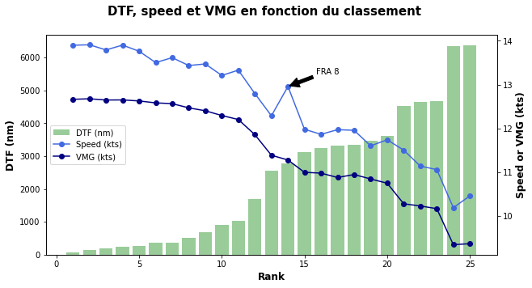

```python
fig1=plt.figure(1,figsize=[10,5]);
ax1=fig1.add_subplot(111);
br=ax1.bar(df_final_info['Rank'],df_final_info['DTF (nm)'],color='g',alpha=0.4);
ax2=ax1.twinx();
ax2.set_prop_cycle(color=['royalblue','navy'])
li=ax2.plot(df_final_info[['Speed (kts)','VMG (kts)','Rank']].set_index('Rank'),marker='o');
line_handles = [mlines.Line2D([], [], color='royalblue', marker='o'),mlines.Line2D([], [], color='navy', marker='o')]

ax1.legend([br]+line_handles,['DTF (nm)','Speed (kts)','VMG (kts)'],loc=6);
ax1.set_xlabel('Rank',fontsize=12,fontweight='bold');
ax1.set_ylabel('DTF (nm)',fontsize=12,fontweight='bold');
ax2.set_ylabel('Speed or VMG (kts)',fontsize=12,fontweight='bold');

ax2.annotate('FRA 8', xy=(df_final_info.loc['FRA 8','Rank'], df_final_info.loc['FRA 8','Speed (kts)']),  xycoords='data',
            xytext=(0.65, 0.85), textcoords='axes fraction',
            arrowprops=dict(facecolor='black', shrink=0.05),
            horizontalalignment='right', verticalalignment='top',
            )

fig1.suptitle('DTF, speed et VMG en fonction du classement',fontsize=15,fontweight='bold');
```

On note sur le graphique ci-dessus une forte relation entre la VMG moyenne sur l'ensemble de la course et la position à l'arrivée : plus la VMG diminue, moins le classement final est bon.  
Cependant, ce graphique semble mettre en évidence une relation encore plus directe entre VMG et DTF : on observe en effet que les sauts de la courbe de DMG (courbe bleu foncée) correspondent exactement aux sauts de DTF (barres vertes)

La figure ci-dessus met également en avant le fait que c'est bien la VMG moyenne et non la vitesse moyenne réelle qui est déterminante pour obtenir un bon classement ou réduire sa DTF.  
On voit notament le bateau FR 8 qui, si le classement était directement lié à la vitesse moyenne pure, serait sûrement classé une ou deux places devant. En l'état, on suppose que l'écart entre sa vitesse réelle et sa DMG s'explique par le fait qu'il a parcouru une grande distance "inutile". Son cas sera investiguée par la suite.

### **Focus sur la relation DTF (distance to finish) - VMG (velocity made good)**

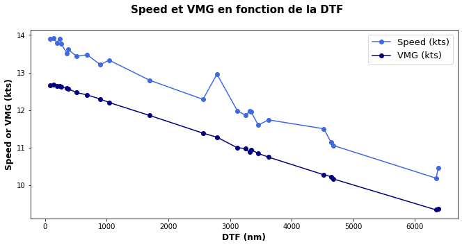

```python
fig2=plt.figure(2,figsize=[11,5]);
ax1=fig2.add_subplot(111);
ax1.set_prop_cycle(color=['royalblue','navy']);

# Affichage des courbes de vitesse et VMG et fonction de la DTF du dernier classement retenu dans le dataset
ax1.plot(df_final_info[['Speed (kts)','VMG (kts)','DTF (nm)']].set_index('DTF (nm)'),marker='o');
ax1.legend(['Speed (kts)','VMG (kts)'],loc=1,fontsize=13)
ax1.set_xlabel('DTF (nm)',fontsize=12,fontweight='bold');
ax1.set_ylabel('Speed or VMG (kts)',fontsize=12,fontweight='bold');
fig2.suptitle('Speed et VMG en fonction de la DTF',fontsize=15,fontweight='bold');
```

La courbe de vitesse confirme que la vitesse et la DTF ne sont pas directement liées.  
En revanche, la relation entre VMG et DTF semble parfaitement linéaire, on peut donc calculer une régression linéaire avec la méthode des moindres carrés :

```python
# Calcul de la relation linéaire entre DTF et VMG par la méthode des moindres carrés
reg = LinearRegression().fit(df_final_info['VMG (kts)'].values.reshape(-1,1),df_final_info['DTF (nm)'])
print(f'DTF = {round(reg.intercept_,2)} {round(reg.coef_[0],2)} x VMG')
R_score=reg.score(df_final_info['VMG (kts)'].values.reshape(-1,1),df_final_info['DTF (nm)'])
print(f'The associated determination coefficient is : {round(R_score,2)}')
```

```
DTF = 23446.8 -1838.07 x VMG
The associated determination coefficient is : 1.0
```

Tentons d'analyser l'équation ci-dessus : la "distance théorique la plus courte restant à parcourir" (DTF) est en théorie égale à : "distance théorique totale de la course - distance utile parcourue" (la distance utile parcourue étant définie comme la projection de la trajectoire réelle sur la trajectoire théorique optimale).  
Or, la VMG est justement égale à la projection de la vitesse réelle sur la trajectoire théorique optimale. Elle correspond donc à : "distance utile parcourue / temps de course total".  
Ainsi, on en déduit que : DTF = distance_theorique_totale - VMG * temps_de_course_total  
Essayons de construire cette nouvelle droite de régression en calculant manuellement "distance_theorique_totale" et "temps_de_course_total" et comparons les coefficients trouvés aux coefficients de la régression effectuée précédemment.

```python
# Calcul de la durée de la course
d_time_FR=datetime.datetime(2020,11,8,13)
a_time_FR=df[('Keys','Signal request')].max()
duration_dt=a_time_FR-d_time_FR
duration_h=(duration_dt.seconds)/3600+duration_dt.days*24

# Calcul de la DTF initiale : on fait la somme de 1) la moyenne des DTF des skippers sur le premier classement et de 2) la moyenne de la distance parcourue par les skippers entre le départ et le premier classement
init_DTF=df.loc[df[('Keys','Publication UTC')]==datetime.datetime(2020,11,8,14),("Last signal","DTF (nm)")].mean()+df.loc[df[('Keys','Publication UTC')]==datetime.datetime(2020,11,8,14),("Last 24h","Distance (nm)")].mean()

# Affichage des résultats et comparaison avec la régression "mathématique"
print('Comparaison des deux méthodes de régression :')
print(f'Intercept (DTF initiale) : méthode des moindres carrés : {round(reg.intercept_,2)} - raisonnement logique : {round(init_DTF,2)} - Ecart : {round(-(reg.intercept_-init_DTF)/np.mean([reg.intercept_,init_DTF])*100,1)}%')
print(f'Coefficient (temps de course total en h) : méthode des moindres carrés : {round(reg.coef_[0],2)} - raisonnement logique : {-duration_h} - Ecart : {round((reg.coef_[0]+duration_h)/np.mean([-reg.coef_[0],duration_h])*100,1)}%')
```

```
Comparaison des deux méthodes de régression :
Intercept (DTF initiale) : méthode des moindres carrés : 23446.8 - raisonnement logique : 24300.1 - Ecart : 3.6%
Coefficient (temps de course total en h) : méthode des moindres carrés : -1838.07 - raisonnement logique : -1921.5 - Ecart : 4.4%
```

L'écart constaté entre les deux méthodes vient probablement des biais de calcul de la DMG et de la DTF  
Les méthode de définition de la trajectoire théorique, puis de projection de la vitesse sur celle-ci ne sont pas forcément totalement rigoureuse. De plus, le fait de moyenner la DMG sur des périodes de 24h peut potentiellement également nuire à la précision des valeurs obtenues.

Pour conclure, comparons les droites de régression construites aux données initiales :

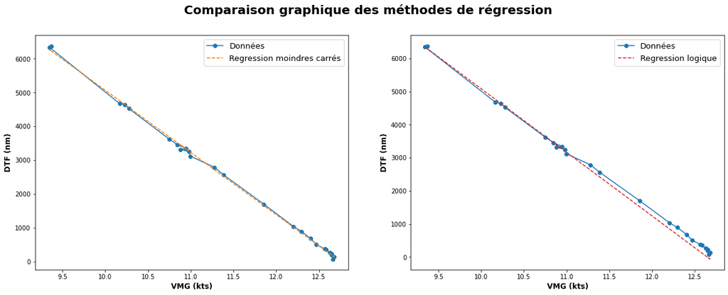

```python
fig3=plt.figure(3,figsize=[20,7]);
ax1=fig3.add_subplot(121);

# Affichage de la régression des moindres carrés par rapport à la courbe de DTF en fonction de DMG issue des données
ax1.plot(df_final_info[['VMG (kts)','DTF (nm)']].set_index('VMG (kts)'),marker='o');
ax1.plot((df_final_info['VMG (kts)']*reg.coef_[0]+reg.intercept_).set_axis(df_final_info['VMG (kts)']),'--',color='tab:orange');
ax1.legend(['Données','Regression moindres carrés'],loc=1,fontsize=13)

# Affichage de la régression manuelle par rapport à la courbe de DTF en fonction de DMG issue des données
ax2=fig3.add_subplot(122);
ax2.plot(df_final_info[['VMG (kts)','DTF (nm)']].set_index('VMG (kts)'),marker='o');
ax2.plot((init_DTF-df_final_info['VMG (kts)']*duration_h).set_axis(df_final_info['VMG (kts)']),'--',color='tab:red')
ax2.legend(['Données','Regression logique'],loc=1,fontsize=13)


for ax in [ax1,ax2]:
    ax.set_xlabel('VMG (kts)',fontsize=12,fontweight='bold');
    ax.set_ylabel('DTF (nm)',fontsize=12,fontweight='bold');

fig3.suptitle('Comparaison graphique des méthodes de régression',fontsize=20,fontweight='bold');
```

On remarque que la régression calculée manuellement "colle" parfaitement à la courbe des données jusqu'à un décrochage qui apparaît pour les VMG supérieures à 11 kts.  
Je n'ai à ce stade pas d'explication à ce "saut", qui peut être interprété de deux manières :

- A partir d'une DTF de 3000 nm et moins, la VMG calculée semble surestimée pour une DTF donnée
- A partir d'une VMG de 11 kts et plus, la DTF semble surestimée pour une VMG donnée

Y'a t'il un biais dans la méthode de calcul utilisée par les organisateurs du Vendée Globe ?

**Conclusion** : l'analyse ci-dessus montre qu'il vaut mieux être prudent lorsque l'on moyenne des indicateurs complexes tels que la VMG. Néanmoins, cet indicateur reste un bon indicateur macro de la performance des skippers.

### **Affichage de la trajectoire de quelques skippers et de l'évolution de leur VMG au long du parcours**

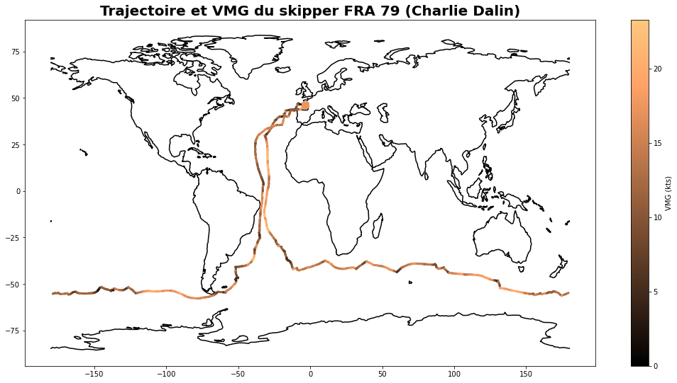

```python
title="Trajectoire et VMG du skipper FRA 79 (Charlie Dalin)"
display_route_VMG("FRA 79",title)
```

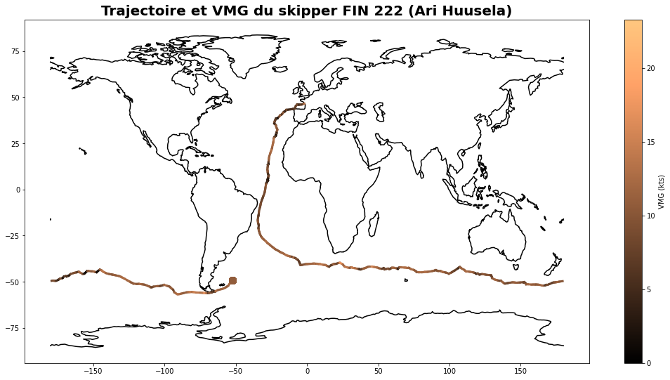

```python
title="Trajectoire et VMG du skipper FIN 222 (Ari Huusela)"
display_route_VMG("FIN 222",title)
```

Charlie Dalin (FRA 79) est le premier skipper à avoir atteint les sables d'Olonne et Ari Huusela (FIN 222) est le skipper qui était le plus éloigné de l'arrivée à ce moment-là.  
La coloration des trajectoires montre bien l'écart de VMG entre les deux skippers.

### **Compromis vitesse - distance et impact des foils**

La VMG est le couplage de deux facteurs :

- La trajectoire du skipper : à vitesse égale, plus sa trajectoire est proche de la trajectoire optimale, plus sa VMG sera élevée.
- La vitesse du skipper : à trajectoire identique, plus sa vitesse est élevée, plus sa VMG sera élevée.

Or, il semble évident que la trajectoire la plus courte n'est pas forcément celle où le bateau sera le plus rapide, d'où la notion de compromis vitesse-distance que l'on va expliciter ci-dessous.  
Pour mettre en avant ce compromis, intéressons-nous au coureur le plus rapide et au coureur le plus lent (en terme de vitesse réelle et non de VMG).

**Coureur le plus rapide VS coureur le plus lent**

```python
fastest_skipper=df_final_info['Speed (kts)'].idxmax()
slowest_skipper=df_final_info['Speed (kts)'].idxmin()
print(f'Le skipper le plus rapide est : {fastest_skipper}')
print(f'Le skipper le plus lent est : {slowest_skipper}')
```

```
Le skipper le plus rapide est : FRA 18
Le skipper le plus lent est : FRA 72
```

Comparons maintenant l'écart de vitesse de distance et de DTF entre le skipper le plus rapide et le plus lent :

```python
speed_difference=(df_final_info.loc[fastest_skipper,'Speed (kts)']-df_final_info.loc[slowest_skipper,'Speed (kts)'])
projected_distance_difference=speed_difference*(df[('Keys','Publication UTC')].max()-df[('Keys','Publication UTC')].min()).days*24
print(f'La différence de vitesse entre le skipper le plus rapide et le moins rapide est de {round(speed_difference,2)} kts')
print(f'Sur la durée totale de la course, soit 80 jours, cet écart de vitesse laisse supposer un écart de distance parcourue entre ces deux skippers de : {round(projected_distance_difference,2)} nm')
```

```
La différence de vitesse entre le skipper le plus rapide et le moins rapide est de 3.72 kts
Sur la durée totale de la course, soit 80 jours, cet écart de vitesse laisse supposer un écart de distance parcourue entre ces deux skippers de : 7142.4 nm
```

```python
real_distance_difference=df_final_info.loc[fastest_skipper,'Distance (nm)']-df_final_info.loc[slowest_skipper,'Distance (nm)']
print(f'D\'après les données de tous les classements, l\'écart entre les distances réellement parcourues par les deux skippers est de  : {round(real_distance_difference,2)} nm')
print('Cela est assez proche de la projection effectuée à partir des vitesses')
```

```
D'après les données de tous les classements, l'écart entre les distances réellement parcourues par les deux skippers est de  : 7144.8 nm
Cela est assez proche de la projection effectuée à partir des vitesses
```

```python
dtf_difference=df_final_info.loc[slowest_skipper,'DTF (nm)']-df_final_info.loc[fastest_skipper,'DTF (nm)']
print(f'L\'écart de DTF entre les deux skippers est en revanche plus faible, il vaut : {round(dtf_difference,2)}')
print(f'On en déduit que sur la distance supplémentaire parcourue par le skipper rapide, {round(dtf_difference/real_distance_difference*100,2)} % ont réellement été utiles, le reste étant des défauts de trajectoire')
```

```
L'écart de DTF entre les deux skippers est en revanche plus faible, il vaut : 6200.0
On en déduit que sur la distance supplémentaire parcourue par le skipper rapide, 86.78 % ont réellement été utiles, le reste étant des défauts de trajectoire
```

Comparons visuellement les trajectoires des deux skippers :

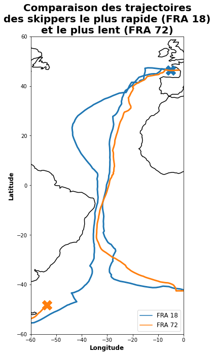

```python
list_skippers=["FRA 18", "FRA 72"]
xlabel=[-60,0]
ylabel=[-60,60]
title="Comparaison des trajectoires\ndes skippers le plus rapide (FRA 18)\net le plus lent (FRA 72)"
compare_routes(list_skippers,title,xlabel,ylabel,downsize=0.6)
```

Lors de la remontée de l'Atlantique, le skipper FRA 18 a effectué un très large coude vers l'ouest, alors que le cap optimal en terme de distance se trouvait au Nord.  
Cela explique probablement une bonne partie de l'excès de distance parcourue par le skipper FRA 18 par rapport à FRA 72.

**Comment expliquer que ces deux skippers adoptent des trajectoires de pilotage aussi différentes ?**

Les bateaux FRA 18 et FRA 72 ont une différence technique importante : la présence ou non de foils

```python
print(f"Dérives du bateau FRA 18 : {df.loc[df[('Keys','Sail N°')]=='FRA 18',('Boat','Nombre de dérives')].unique()[0]}")
print(f"Dérives du bateau FRA 72 : {df.loc[df[('Keys','Sail N°')]=='FRA 72',('Boat','Nombre de dérives')].unique()[0]}")
```

```
Dérives du bateau FRA 18 : foils
Dérives du bateau FRA 72 : 2
```

Mais l'importante différence dans le choix de trajectoires ainsi que l'écart de performance constaté entre les deux skippers peut-il simplement s'expliquer par la présence ou non de foil sur le voilier ?  
Pour le vérifier, étudions l'impact du foil sur l'ensemble des voiliers ayant participé au Vendée Globe.

Commençons d'abord par regarder la proportion de bateaux au départ possédant un foil :

```python
df_boats[('Boat','Nombre de dérives')].isin(['foils','foiler']).value_counts()
```

```
True     19
False    14
Name: (Boat, Nombre de dérives), dtype: int64
```

Il y a donc un nombre suffisemment significatif de voiliers avec et sans foil pour que des comparaisons statistiques entre ces deux popuations aient du sens

La proportion de bateaux encore en lice après 80 jours et possédant un foil est la suivante :

```python
df_final_info['Foils']=df_boats[('Boat','Nombre de dérives')].isin(['foils','foiler']).set_axis(df_boats[('Keys','Numéro de voile')])
df_final_info.value_counts('Foils')
```

```
Foils
False    13
True     12
dtype: int64
```

Pour le vérifier, intéressons nous maintenant au gain de performance permis par un foil :

```python
df_final_info['Distance ratio']=(init_DTF-df_final_info['DTF (nm)'])/df_final_info['Distance (nm)']
```

```python
df_stats_foils=df_final_info.groupby('Foils').mean()
print('Comparaison des performances des skippers avec foil VS sans foil :')
((df_stats_foils.loc[True]-df_stats_foils.loc[False])/((df_stats_foils.loc[True]+df_stats_foils.loc[False]))*100).apply(lambda x : f'{round(x,1)} %').iloc[[0,5,1,3,4]]
```

```
Comparaison des performances des skippers avec foil VS sans foil :
```

```
Speed (kts)         4.2 %
Distance ratio     -0.5 %
VMG (kts)           3.7 %
Rank              -26.8 %
DTF (nm)          -34.5 %
dtype: object
```

Globalement, les skippers équipés d'un foil ont une vitesse réelle 4,2% plus élevée  
Leurs choix de trajectoire semblent légèrement moins orientés vers le trajet le plus court puisque leur ratio distance utile parcourue / distance réelle parcourue est légèrement moins bon que pour les bateaux sans foil (-0.5%).  
L'impact du foil sur la VMG reflète bien le fait que celle-ci est un compromis entre vitesse et trajctoire.

Au global, l'impact des foils est en tous cas extrêmement positif puisqu'au bout de 80 jours, la DTF des coureurs avec un foil est 34% plus faible que celle des coureurs sans foil. Naturellement, leur classement est donc meilleur également

### **Comparaison des données de navigation des skippers à distance parcourue égale**

Précédemment, on a travaillé avec les statistiques cumulées des skipers à durée de course égale, à savoir un peu plus de 80 jours. Or, sur cette période, certains skippers ont parcouru des distances bien plus grandes que d'autres et les environnements traversés sont donc très divers. Pour comparer le pilotage des différents skippers, ont adopte désarmais une approche "à distance utile parcourue égale".

```python
# --Avant de passer aux comparaisons, on crée une fonction qui pour une DTF donnée passée en argument retourne un dataframe qui associe pour chaque skipper un ensemble de statistiques calculées entre le départ et la DTF fixée
# --Si un skipper n'a pas atteint la DTF en argument, il n'est pas présent dans le dataframe retourné
def calc_df_dtf_treshold(df,dtf_treshold):

    # On travaille sur un nouveau dataframe par sécurité
    df_dist=df.copy()

    # On ne garde que les classements de 14h pour pouvoir à chaque fois prendre les valeurs sur les last 24h
    df_dist=df_dist.loc[df_dist[('Keys','Publication UTC')].dt.time==datetime.time(hour=14)]
    # On crée une colonne distance cumulée qui pour l'instant ne contient que les distances sur les dernières 24h
    df_dist[('Last signal','Distance cumulée (nm)')]=df_dist.loc[:,('Last 24h','Distance (nm)')]

    # Grâce à un group by, on calcule la distance cumulée parcourue pour chaque skipper
    def cum_dist(group):
        group[('Last signal','Distance cumulée (nm)')]=group[('Last signal','Distance cumulée (nm)')].cumsum()
        return group
    df_dist=df_dist.groupby(('Keys','Sail N°')).apply(cum_dist)

    # On crée maintenant un index qui, pour une dtf donnée, va donner pour chaque skipper le premier signal ayant franchit cette valeur de DTF
    def select_closest_to_dtf(group,dtf_value):
        try:
            ret=int(group.loc[group[('Last signal','DTF (nm)')]<dtf_value].sort_values(('Last signal','DTF (nm)')).tail(1).index[0])
        except:
            ret=np.nan
        return ret
    s_index=df_dist.groupby(('Keys','Sail N°')).apply(select_closest_to_dtf, dtf_treshold).dropna()

    # On récupère dans deux séries distinctes la moyenne de la vitesse et de la VMG du début jusqu'à la ligne ou le seuil de dtf fixé est atteint (pour chaque coureur)
    def extract_avg_to_ind(group,s_index,column):
        try:
            ind=group.loc[group.index.isin(s_index.values)].index.values[0]
            ret=group.loc[group.index<=ind,column].mean()
        except:
            ret=np.nan
        return ret
    s_speed_moy=df_dist.groupby(('Keys','Sail N°')).apply(extract_avg_to_ind, s_index, ('Last 24h','Speed (kts)'))
    s_VMG_moy=df_dist.groupby(('Keys','Sail N°')).apply(extract_avg_to_ind, s_index, ('Last 24h','VMG (kts)'))

    s_time=df_dist.loc[s_index,[("Keys","Signal reception"),("Keys","Sail N°")]].set_index(("Keys","Sail N°"))-df_dist[("Keys", "Signal request")].min()

    # On récupère pour chaque coureur la distance cumulée et la dtf de la ligne correspondant au dépassement du seuil de DTF fixé
    df_dist=df_dist.loc[s_index.values].droplevel(0,axis=1).set_index('Sail N°')[['Distance cumulée (nm)','DTF (nm)']]
    # Puisqu'on ne peut pas récupérer le moment exact où chaque skipper franchit le seuil de DTF, on fait le rapport distance / DTF qui permet d'obtenir un indicateur de l'efficacité des trajectoires des skippers
    s_dist_utile=init_DTF-df_dist['DTF (nm)']
    df_dist['Distance ratio']=s_dist_utile/df_dist['Distance cumulée (nm)']
    # On ajoute les vitesses et VMG moyennes calculées auparavant
    df_dist['VMG (kts)']=s_VMG_moy
    df_dist['Speed (kts)']=s_speed_moy
    df_dist['Time to reach treshold']=s_time

    # On se débarasse des colonnes non utiles (distance cumuléé et rang n'ont pas beaucoup d'intérêt ici car on est pour chaque coureur à un moment de la course différent)
    df_dist=df_dist[df_dist.columns[2:6]]

    # On trie en fonction du classement qu'occupaient les skippers au moment où ils ont passé ce seuil de dtf (il peut donc y avoir des doublons sur le rank)
    df_dist=df_dist.sort_values(['Time to reach treshold','VMG (kts)'],ascending=[True,False])

    return df_dist
```

**Définition de "checkpoints" le long du parcours**

Commençons par définir différents checkpoints, c'est à dire des points intermédiaires de la course au niveau desquels on veut comparer les skippers sur des portions de course parcourues égales. Ces checkpoints sont définis en fonction de la distance to finish (DTF).

```python
tresholold_tick=5000
list_dtf_treshold=np.arange(25000,0,-tresholold_tick)[1:]
# list_dtf_treshold=[19000,15000,11000,7000]
print(f'Liste des checkpoints de DTF étudiés : {list_dtf_treshold} (distances à l\'arrivée en nm de trajectoire optimale restants)')
```

```
Liste des checkpoints de DTF étudiés : [20000 15000 10000  5000] (distances à l'arrivée en nm de trajectoire optimale restants)
```

Représentons maintenant ces checkpoints sur la trajectoire d'un skipper :

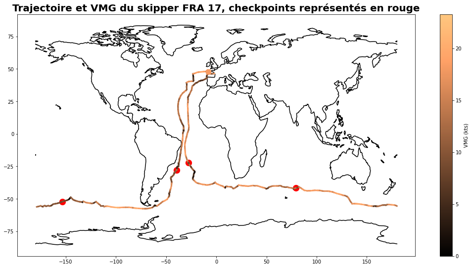

```python
# Latitude correspondant à un DTF donné
skipper="FRA 17"
title=f'Trajectoire et VMG du skipper {skipper}, checkpoints représentés en rouge'
long_checkpoints=[]
lat_checkpoints=[]
for i in range(len(list_dtf_treshold)):
    dtf_value=list_dtf_treshold[i]
    long_checkpoints.append(df.loc[(df[('Last signal','DTF (nm)')]<dtf_value) & (df[('Keys','Sail N°')]==skipper)].sort_values(('Last signal','DTF (nm)')).tail(1)[[('Last signal','Longitude')]].values)
    lat_checkpoints.append(df.loc[(df[('Last signal','DTF (nm)')]<dtf_value) & (df[('Keys','Sail N°')]==skipper)].sort_values(('Last signal','DTF (nm)')).tail(1)[[('Last signal','Latitude')]].values)

display_route_VMG(skipper,title,long_checkpoints,lat_checkpoints)
```

Description des portions délimitées par ces checkpoints :

- Portion 1 : descente de l'Atlantique
- Portion 2 : virage vers l'est et trajectoire rectiligne autour d'une latitude de -40°. Au début de cette portion 2, on remarque un ralentissement majeur du skipper (baisse de la VMG). On retrouve ce phénomène chez de nombreux skippers.
- Portion 3 : trajectoire assez rectiligne entre -40 et -60° de latitude
- Portion 4 : trajectoire rectiligne autour de -55° de latitude et début de la remontée de l'Atlantique.

A noter que le checkpoint 4 ne correspond pas uniquement à la portion 4 mais à l'ensemble des portions 1 à 4.

**Comparaison de l'optimisation de trajectoire et de la vitesse moyenne des skippers du départ jusqu'aux différents checkpoints.**  
Pour caractériser l'optimisation de trajectoire, le paramètre retenu est appelé distance ratio : c'est le rapport distance utile parcourue / distance réelle parcourue. Plus ce ratio est proche de 1, plus la trajectoire adoptée est proche de la trajectoire idéale.

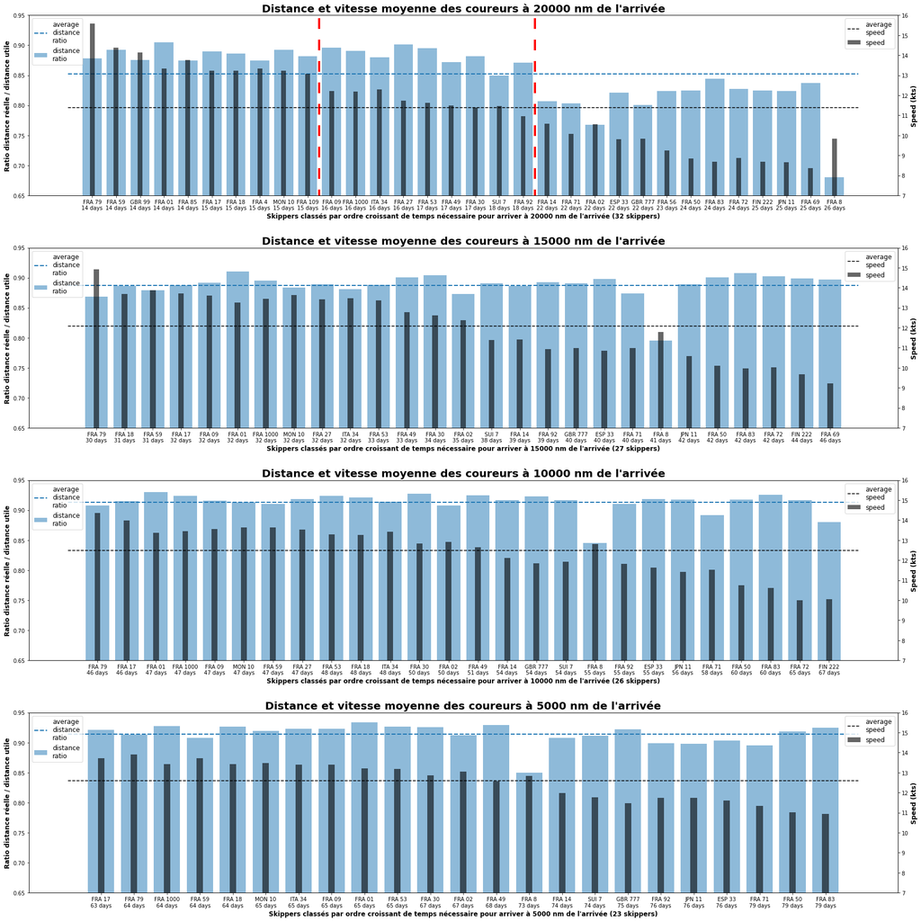

```python
# Le nombre de graphes dépend directement de l'écart entre les différents checkponts de DTF que l'on veut analyser (définis ci-dessus)

# On instancie la figure et le nombre d'axes adéquats
fig4=plt.figure(4,figsize=[6*len(list_dtf_treshold),24]);
ax1=fig4.subplots(len(list_dtf_treshold),1)
ax2=[0]*len(list_dtf_treshold)
# On instancie les objets utilisés pour récupérer les légendes
br1=[0]*len(list_dtf_treshold)
br2=[0]*len(list_dtf_treshold)

# Pour chaque "checkpoint" de DTF, on récupère les statistiques de l'ensemble des coureurs et on les affiche sur un graphe
for i in range(len(list_dtf_treshold)):

    dtf_treshold=list_dtf_treshold[i]
    df_dist=calc_df_dtf_treshold(df,dtf_treshold)

    # On génère les valeurs à afficher sur l'axe des abscisses (numéro du skipper et durée pour atteindre le checkpoint DTF)
    # Même si le skippers n'a pas atteint tous les checkpoints, on veut récupérer autant de valeurs que de checkpoints donc un complète avec des indications adéquates
    x_skipper=df_dist.index
    x_time=df_dist['Time to reach treshold'].dt.days+1
    x_values=[f"{x_skipper[i]}\n{x_time[i]} days" for i in range(len(df_dist))]

    ax1[i].bar(x_values,df_dist['Distance ratio'],alpha=0.5,label='distance\nratio');
    ax1[i].set_ylim(0.65,0.95);
    ax1[i].hlines(df_dist['Distance ratio'].mean(),-1,len(df_dist),linestyle='--',linewidth=2,label='average\ndistance\nratio')
    ax1[i].set_xlabel(f'Skippers classés par ordre croissant de temps nécessaire pour arriver à {dtf_treshold} nm de l\'arrivée ({len(df_dist)} skippers)',fontsize=12,fontweight='bold')
    ax1[i].set_ylabel('Ratio distance réelle / distance utile',fontsize=12,fontweight='bold')
    ax1[i].set_title(f'Distance et vitesse moyenne des coureurs à {dtf_treshold} nm de l\'arrivée',fontsize=20,fontweight='bold')
    ax1[i].legend(fontsize=12,loc='upper left')

    ax2[i]=ax1[i].twinx()
    ax2[i].bar(x_values,df_dist['Speed (kts)'],width=0.2,align='center',color='k',alpha=0.6,label='speed');
    ax2[i].set_ylim(7,16);
    ax2[i].hlines(df_dist['Speed (kts)'].mean(),-1,len(df_dist),color='k',linestyle='--',label='average\nspeed')
    ax2[i].set_ylabel('Speed (kts)',fontsize=12,fontweight='bold')
    ax2[i].legend(fontsize=12)

ax1[0].vlines(9.49,0,1,linewidth=4,linestyle=(0, (5,5)),color='red')
ax1[0].vlines(18.49,0,1,linewidth=4,linestyle=(0, (5,5)),color='red')

plt.tight_layout(h_pad=3)
```

**Les graphes ci-dessus permettent de tirer quelques enseignements :**

En 80 jours, 23 skippers sur les 33 skippers engagés arrivent à moins de 5000 nm de l'arrivée. Parmi les 10 qui n'y parviennent pas :

```python
list_DTF_20000=calc_df_dtf_treshold(df,20000).index
list_DTF_5000=calc_df_dtf_treshold(df,5000).index
list_5000_non_atteint=set(df[('Keys','Sail N°')]).difference(list_DTF_5000)

list_5000_non_atteint_abadons=list_5000_non_atteint.difference(df_final_info.index)
list_5000_non_atteint_en_course=list_5000_non_atteint.intersection(df_final_info.index)
print(f"  - {len(list_5000_non_atteint_abadons)} ont abandonné avant la fin des 80 jours : {', '.join(list_5000_non_atteint_abadons)}")
print(f"  - {len(list_5000_non_atteint_en_course)} sont encore en course mais n'on pas atteint le checkpoint : {', '.join(list_5000_non_atteint_en_course)}")
```

```
  - 8 ont abandonné avant la fin des 80 jours : FRA 109, FRA 69, FRA 6, FRA 56, FRA 4, GBR 99, FRA 85, FRA 27
  - 2 sont encore en course mais n'on pas atteint le checkpoint : FRA 72, FIN 222
```

**Graphe 1** : Sur les premiers 4300 permiers nm utiles (DTF = 20 000), les performances des coureurs sont assez hétérogènes, et on peut distinguer trois grandes catégories de skippers :

- Une première catégorie de skippers qui a dès le départ maintenu une vitesse élevée tout en ayant eu une trajectoire assez optimisée (groupe 1)
- Un deuxième groupe de 9 skippers qui a a adopté une trajectoire assez optimisée mais dont la vitesse est moins importante que le premier groupe (groupe 2)
- Enfin, un troisème groupe de 13 skippers a adopté une trajectoire peu optimisée alliée à une faible vitesse (groupe 3)

Il peut être intéressant de regarder comment être membre d'un de ces groupes après les 4300 permiers nm utiles détermine ou non la position finale d'un skipper sur le Vendée Globe

```python
list_class_1_DTF_20000=calc_df_dtf_treshold(df,20000)[0:10].index
list_class_2_DTF_20000=calc_df_dtf_treshold(df,20000)[10:19].index
list_class_3_DTF_20000=calc_df_dtf_treshold(df,20000)[19:35].index

percent_arrival_classe_1=len(list_class_1_DTF_20000.intersection(list_DTF_5000))/len(list_class_1_DTF_20000)
percent_arrival_classe_2=len(list_class_2_DTF_20000.intersection(list_DTF_5000))/len(list_class_2_DTF_20000)
percent_arrival_classe_3=len(list_class_3_DTF_20000.intersection(list_DTF_5000))/len(list_class_3_DTF_20000)

print(f' - Au sein du groupe 1, {round(percent_arrival_classe_1*100,1)} % des skippers arrivent à moins de 5000 nm de l\'arrivée au bout de 80 jours')
print(f' - Au sein du groupe 2, cette proportion est de  {round(percent_arrival_classe_2*100,1)} %')
print(f' - Au sein du groupe 3, elle est de  {round(percent_arrival_classe_3*100,1)} %')
```

```
 - Au sein du groupe 1, 60.0 % des skippers arrivent à moins de 5000 nm de l'arrivée au bout de 80 jours
 - Au sein du groupe 2, cette proportion est de  88.9 %
 - Au sein du groupe 3, elle est de  69.2 %
```

En regard des chiffres ci-dessus, on conclut que bien commencer la course ne prédispose pas à la terminer puisque c'est le groupe 1 qui place le plus faible pourcentage de coureurs dans les 5000 derniers nm au bout de 80 jours

```python
top_5_final=df_final_info.sort_values('Rank').head(5).index
print(f"En revanche, le top 5 final de la course est entièrement constitué de skippers du groupe 1, dont voici la liste : {list_class_1_DTF_20000.intersection(top_5_final).values}")
```

```
En revanche, le top 5 final de la course est entièrement constitué de skippers du groupe 1, dont voici la liste : ['FRA 79' 'FRA 59' 'FRA 17' 'FRA 18' 'MON 10']
```

**Conclusion** : les skippers du groupe 1 prennent probablement plus de risques et/ou leurs voiliers équipés de foils sont plus fragiles : ils ont donc plus de chances de gagner mais également plus de chance de ne pas rallier l'arrivée. Ce compromis risque d'abandon VS performance avait déjà été mis en avant précédemment lors de l'analyse de l'impact des foils.

**Graphes 2, 3 et 4** : Aux checkpoints 15000 nm, 10000 nm et 5000 nm, les ratios de distance sont très semblables pour tous les coureurs, et la différence entre ceux-ci se fait principalement sur la vitesse. Il semblerait donc que les skippers effectuent principalement des choix de trajectoires différentes lors de la descente de l'Atlantique, puis que tous suivent plus ou moins une trajectoire semblable (ou du moins que les choix des uns et des autres finissent par s'équilibrer au fur et à mesure de la course).

Un skipper présente cependant un profil particulier sur les graphes ci-dessus : c'est le bateau FR 8, piloté par Jérémie Beyou.  
On souhaiterait se pencher spécifiquement sur son cas ainsi que sur d'autres coureurs. Pour cela, on trace les graphes d'évolution du pilotage de différents coureurs au fur et à mesure des checkpoints (même approche que ci-dessus, mais en isolant les coureurs un à un).

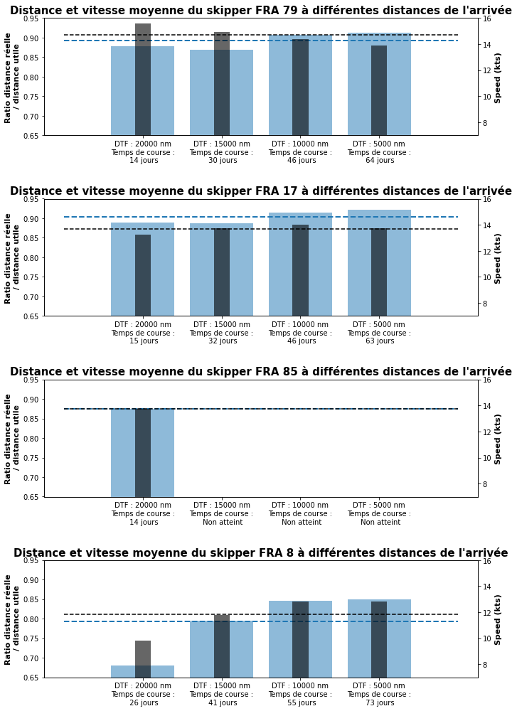

```python
list_skippers=['FRA 79','FRA 17','FRA 85','FRA 8']
treshold_tick=5000
list_dtf_treshold=np.arange(25000,0,-treshold_tick)[1:]

fig5=plt.figure(5,figsize=[10,3.5*len(list_skippers)]);
ax1=fig5.subplots(len(list_skippers),1)
ax2=[0]*len(list_skippers)

for j in range(len(list_skippers)):
    skipper=list_skippers[j]
    # On génère un dataframe vide contenant les colonnes adaptées à recueillir le distance ratio, le temps de parcours, la vitesse et la VMG
    df_skipper=pd.DataFrame(columns=calc_df_dtf_treshold(df,5000).columns)
    # Pour un coureur donnée, on alimente ce dataframe avec ses statistiques à chacun des checkpoints
    for i in range(len(list_dtf_treshold)):
        dtf_treshold=list_dtf_treshold[i]
        df_dist=calc_df_dtf_treshold(df,dtf_treshold)
        try:
            df_skipper.loc[dtf_treshold]=df_dist.loc[skipper]
        except: # On prévoit le cas ou un coureur n'aurait pas atteint un checkpoint donné
            pass

    # On génère les valeurs à afficher sur l'axe des abscisses (valeur du checkpoint DTF et durée pour l'atteindre)
    # Même si le skippers n'a pas atteint tous les checkpoints, on veut récupérer autant de valeurs que de checkpoints donc un complète avec des indications adéquates
    x_dtf=[str(dtf_treshold) for dtf_treshold in list_dtf_treshold]
    x_time=['Non atteint']*len(list_dtf_treshold)
    x_time_skipper=[f"{df_skipper.loc[dtf_treshold,'Time to reach treshold'].days+1} jours" for dtf_treshold in df_skipper.index]
    x_time[0:len(x_time_skipper)]=x_time_skipper
    x_values=[f"DTF : {x_dtf[i]} nm\nTemps de course :\n {x_time[i]}" for i in range(len(list_dtf_treshold))]

    # On Récupère les ratios de distance moyens du skipper aux différents checkpoints
    # Même si le skippers n'a pas atteint tous les checkpoints, on veut récupérer autant de valeurs que de checkpoints donc un complète avec des 0
    dist_ratio=[0]*len(list_dtf_treshold)
    dist_ratio_skipper=df_skipper['Distance ratio'].values
    dist_ratio[0:len(dist_ratio_skipper)]=dist_ratio_skipper

    # On Récupère les vitesses moyennes du skipper aux différents checkpoints
    # Même si le skippers n'a pas atteint tous les checkpoints, on veut récupérer autant de valeurs que de checkpoints donc un complète avec des 0
    speed=[0]*len(list_dtf_treshold)
    speed_skipper=df_skipper['Speed (kts)'].values
    speed[0:len(speed_skipper)]=speed_skipper

    ax1[j].bar(x_values,dist_ratio,alpha=0.5)
    ax1[j].set_ylim(0.65,0.95);
    ax1[j].hlines(df_skipper['Distance ratio'].mean(),-1,len(dist_ratio),linestyle='--',linewidth=2)
    ax1[j].set_ylabel('Ratio distance réelle\n / distance utile',fontsize=11,fontweight='bold')
    ax1[j].set_title(f'Distance et vitesse moyenne du skipper {skipper} à différentes distances de l\'arrivée',fontsize=15,fontweight='bold')


    ax2[j]=ax1[j].twinx()
    ax2[j].bar(x_values,speed,width=0.2,align='center',color='k',alpha=0.6)
    ax2[j].set_ylim(7,16);
    ax2[j].hlines(df_skipper['Speed (kts)'].mean(),-1,len(speed),color='k',linestyle='--')
    ax2[j].set_ylabel('Speed (kts)',fontsize=11,fontweight='bold')

plt.tight_layout(h_pad=3)
```

Les deux premiers graphes correspondent aux skippers :

- FRA 79 : Chalie Dalin (2ème au checkpoint des 5000 km, premier arrivé aux Sables d'Olonne mais deuxième de l'épreuve du fait des compensations du jury)
- FRA 17 : Yannick Bestaven (1er au checkpoint des 5000km, troisième arrivé aux Sables d'Olonne mais premier de l'épreuve du fait des compensations du jury

On remarque que les performances des deux skippers sur la première partie de course a été très différentes : avec un ratio de distance équivalent, Bestaven a eu une vitesse beaucoup plus faible que Dalin. Il a donc franchit le checkpoint DTF 20 000 en 6ème position alors que Dalin était premier. Il a fallu attendre le 3ème checkpoint pour que Bestaven ait compensé cet écart.

Le dernier graphique est le cas de Jérémie Beyou (FRA 8) dont la singularité avait déjà été soulevée précédemment. Il semble avoir parcouru énormément de kilomètres inutiles car son distance ratio est extrêmement faible. En fait, suite à des dommages sur son appareil, il est retourné vers les Sables d'Olonnes après 4 jours de course pour effectuer des réparations, puis est reparti ensuite. Les indicateurs utilisés ci-dessus sont donc bien pertinents, puisqu'ils mettent en avant le caractère "inutile" (en terme de trajectoire) de l'aller retour effectué.

Le troisième graphique correspond à Kevin Escoffier, skippeur classé ci-dessus dans le groupe 1 et ayant abandonné le lundi 30 novembre du fait de dommages sur son voilier. Le naufrage de Kevin Escoffier constitue un incident de course majeur sur lequel il peut être intéressant de s'attarder.

Sur le tableau ci-dessous, on voit précisément qu'à partir de 15h le 30 novembre, la direction de course continue d'essayer de collecter les informations de Kevin Escoffier mais que plus aucun nouveau signal n'est reçu de la part du skipper.

```python
print('Signaux émis et reçus par la direction de course à destination de Kevin Escoffier :')
df.loc[(df[('Keys','Publication UTC')]>=datetime.datetime(2020,11,30,4)) & (df[('Keys','Publication UTC')]<datetime.datetime(2020,12,1,14)) & (df[('Keys',"Sail N°")]=="FRA 85"),[('Keys','Signal request'),('Keys','Signal reception')]]#,df.columns[0:3].union(df.columns[20:23])].head(10)
```

```
Signaux émis et reçus par la direction de course à destination de Kevin Escoffier :
```

|  | Keys Signal request | Keys Signal reception |
| --- | --- | --- |
| 4176 | 2020-11-30 04:30:00 | 2020-11-30 04:30:00 |
| 4208 | 2020-11-30 08:30:00 | 2020-11-30 08:30:00 |
| 4240 | 2020-11-30 11:30:00 | 2020-11-30 11:30:00 |
| 4272 | 2020-11-30 14:30:00 | 2020-11-30 14:30:00 |
| 4304 | 2020-11-30 17:30:00 | 2020-11-30 15:00:00 |
| 4339 | 2020-11-30 21:30:00 | 2020-11-30 15:00:00 |
| 4374 | 2020-12-01 04:30:00 | 2020-11-30 15:00:00 |

En réalité, l'incident s'est déroulé 30 novembre 2020 à 14h46 très exactement. Le tableau ci-dessus donne donc une indication assez précise sur l'heure du naufrage.  
Lien : https://www.ouest-france.fr/vendee-globe/vendee-globe-ce-que-l-on-sait-du-naufrage-de-kevin-escoffier-7067749

Lorsuqe le naufrage a été remonté à la direction de course, plusieurs skippers ont tenté de secourir Kevin Escoffier. Etudions l'impact de ces opérations de sauvetage sur l'allure des skippers :

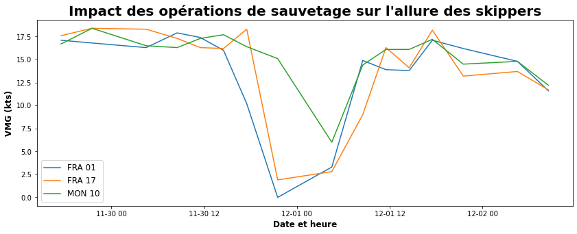

```python
df_sauvetage=df.loc[(df[('Keys','Publication UTC')]>=datetime.datetime(2020,11,29,17)) & (df[('Keys','Publication UTC')]<datetime.datetime(2020,12,2,10)) & df[('Keys',"Sail N°")].isin(["FRA 01","FRA 17","MON 10"]),[('Keys','Sail N°'),('Last signal','Rank'),('Since last report','VMG (kts)'),('Keys','Signal request')]].droplevel(0,axis=1).set_index('Signal request')

fig6=plt.figure(6,figsize=[14,5]);
ax1=fig6.add_subplot(1,1,1)

for skipper in ["FRA 01","FRA 17","MON 10"]:
    ax1.plot(df_sauvetage.loc[df_sauvetage['Sail N°']==skipper,'VMG (kts)'],label=skipper)

ax1.legend(fontsize=12)
ax1.set_xlabel('Date et heure',fontsize=12,fontweight='bold')
ax1.set_ylabel('VMG (kts)',fontsize=12,fontweight='bold')
ax1.set_title(f'Impact des opérations de sauvetage sur l\'allure des skippers',fontsize=20,fontweight='bold');
```

Enfin, regardons maintenant comment les skippers ont adapté leurs trajectoires pour porter secours à Kevin Escoffier :

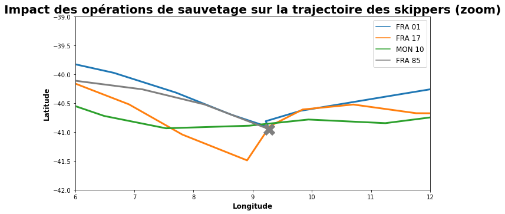

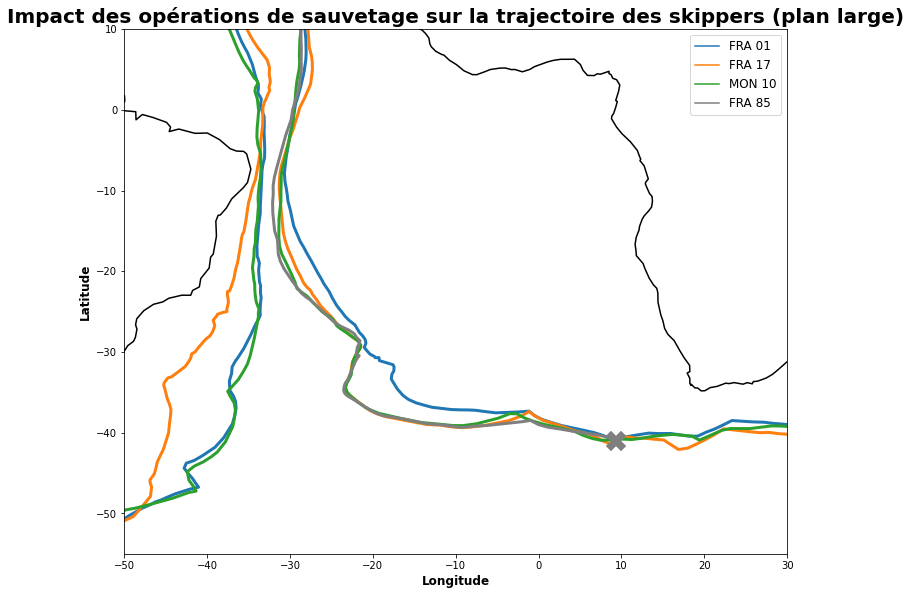

```python
list_skippers=['FRA 01','FRA 17','MON 10','FRA 85']

xlim=[6,12]
ylim=[-42,-39]
title='Impact des opérations de sauvetage sur la trajectoire des skippers (zoom)'
compare_routes(list_skippers,title,xlim,ylim,downsize=0.6)

xlim=[-50,30]
ylim=[-55,10]
title='Impact des opérations de sauvetage sur la trajectoire des skippers (plan large)'
compare_routes(list_skippers,title,xlim,ylim,downsize=0.66)
```

On voit que c'est Yannick Bestaven (FRA 17) qui a le plus modifié sa trajectoire, tandis que Jean Le Cam (FRA 01) l'a légèrement modifiée et Boris Herrman (MON 10) beaucoup moins.  
Le fait que ce soit Jean Le Cam qui ait perdu le plus de temps lors du sauvetage ne s'explique donc pas par le fait qu'il soit le skipper qui a le plus modifié sa trajectoire, mais parce que c'est lui qui a "stationné" le plus longtemps dans la zone pour secourir Kevin Escoffier (c'est d'ailleurs lui qui l'a reccueilli).  
On remarque par ailleurs que les modifications de trajectoires effectuées ici sont faibles par rapport au décrochage effectué par Boris Hermann, Kevin Escoffier et Yannick Bestaven autour de la longitude -25° (mais on suppose que ce décrochage faisait sens en regard des conditions météorologiques, ce qui n'est pas le cas de la modification de trajectoire en vue du sauvetage).

On remarque par ailleurs la différence de pilotage des voiliers avec foil et sans foil : pour rechercher des conditions de navigation optimale ou peut-être éviter les avaries météorologiques, les pilotes dont le voilier possède un foil (FRA 17, MON 10 et FRA 85) effectuent un décrochage significatif vers le sud autour de la longitude -25°, alors que le seul skipper sur les 4 sans foil, Jean Le Cam (FRA 01), suit une trajectoire beaucop plus directe.  
On retrouve ici la notion de **compromis distance-vitesse-fragilité** développé dans les parties précédentes, et qui résume assez bien toute la complexité du Vendée Globe.